# Statistics

In the course of your analyses you will both want to and need to conduct statistical tests. It is important that you are equipped to perform these tests in R as well. Teaching you statistical concepts is outside of the scope of this book. For an introduction to statistical concepts using R, I recommend reading David Dalpiaz’s free and open [*R for Statistical Learning*](https://daviddalpiaz.github.io/r4sl/)[^1]. In this section we will review *how* to implement statistical tests and extract useful information from them as well. We will cover t-tests, ANOVA, and linear regression.

To explore these statistics we will use data from Inside Airbnb. Of interest is the relationship between price and superhosts, price and room type, and finally how both superhosts and room type contribute to price.

We will use data from both the `hosts` and `listings` datasets. The former contains superhost data while the later has both the price and room type information. First we will read in both of these datasets.

```r
library(tidyverse)

listings <- read_csv("../data/airbnb/listings.csv")
hosts <- read_csv("../data/airbnb/hosts.csv")

glimpse(listings)
```

```
## Rows: 3,799
## Columns: 7
## $ id               <dbl> 3781, 5506, 6695, 8789, 10730, 10813, 10986, 16384, …
## $ neighborhood     <chr> "East Boston", "Roxbury", "Roxbury", "Downtown", "Do…
## $ room_type        <chr> "Entire home/apt", "Entire home/apt", "Entire home/a…
## $ price            <dbl> 125, 145, 169, 99, 150, 179, 125, 50, 154, 115, 148,…
## $ minimum_nights   <dbl> 28, 3, 3, 91, 91, 91, 91, 91, 29, 1, 2, 2, 2, 6, 3, …
## $ availability_365 <dbl> 68, 322, 274, 247, 29, 0, 364, 365, 304, 285, 62, 24…
## $ host_id          <dbl> 4804, 8229, 8229, 26988, 26988, 38997, 38997, 23078,…
```

```r
glimpse(hosts)
```

```
## Rows: 1,335
## Columns: 9
## $ id              <dbl> 4804, 8229, 26988, 38997, 23078, 71783, 85130, 85770,…
## $ name            <chr> "Frank", "Terry", "Anne", "Michelle", "Eric", "Lance"…
## $ since_year      <dbl> 2008, 2009, 2009, 2009, 2009, 2010, 2010, 2010, 2010,…
## $ since_month     <chr> "12", "02", "07", "09", "06", "01", "02", "02", "03",…
## $ since_day       <chr> "03", "19", "22", "16", "24", "19", "24", "26", "23",…
## $ response_rate   <chr> "100%", "100%", "100%", "92%", "50%", "98%", "66%", "…
## $ acceptance_rate <chr> "50%", "100%", "84%", "17%", "N/A", "98%", "97%", "10…
## $ superhost       <dbl> 1, 1, 1, 0, 0, 0, 0, 0, 0, 0, 0, 1, 0, 0, 0, 0, 0, 1,…
## $ n_listings      <dbl> 5, 2, 9, 13, 3, 40, 7, 4, 1, 2, 1, 1, 5, 1, 1, 1, 1, …
```

In order to join these two tibbles together we need to figure out what the common identifiers are. In `listings` we can infer that the **primary key** is `id` while the **foreign key** is `host_id`. While the `hosts` tibble only has one `id` column. Clearly the join needs to be between `host_id` and `id` from `listings` and `hosts` respectively. We will perform a left join then select the columns `price`, `room_type` and `superhost` and assign that to the object `airbnb`.

```r
airbnb <- left_join(listings, hosts, by = c("host_id" = "id")) %>%
  select(price, room_type, superhost)

glimpse(airbnb)
```

```
## Rows: 3,799
## Columns: 3
## $ price     <dbl> 125, 145, 169, 99, 150, 179, 125, 50, 154, 115, 148, 275, 2…
## $ room_type <chr> "Entire home/apt", "Entire home/apt", "Entire home/apt", "E…
## $ superhost <dbl> 1, 1, 1, 1, 1, 0, 0, 0, 0, 0, 0, 0, 0, 0, 1, 0, 1, 0, 0, 0,…
```

Before we can engage in any statistical testing we should do our due diligence and first visualize the relationship before we test it. Because we are comparing a group to a continuous variable a boxplot will suffice.

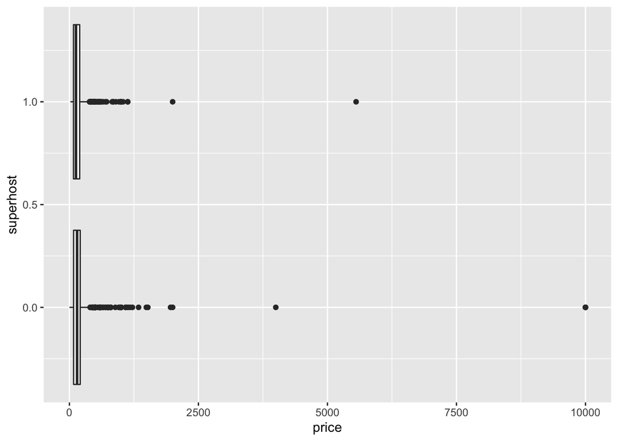

```r
ggplot(airbnb, aes(price, superhost, group = superhost)) +
  geom_boxplot()
```

> Note that we are setting the group to `superhost` this is because it is dummy coded as a numeric value. ggplot is attempting to consider it numeric rather than categorical.

Clearly there are some noticeable outliers above the $2,500 mark. Let’s filter out these values before we get on to our testing and while we’re at it, let’s convert `superhost` to a factor with `factor()`. Save the the filtered results to `bnb_filt`. Recreate the above visualization with the new object.

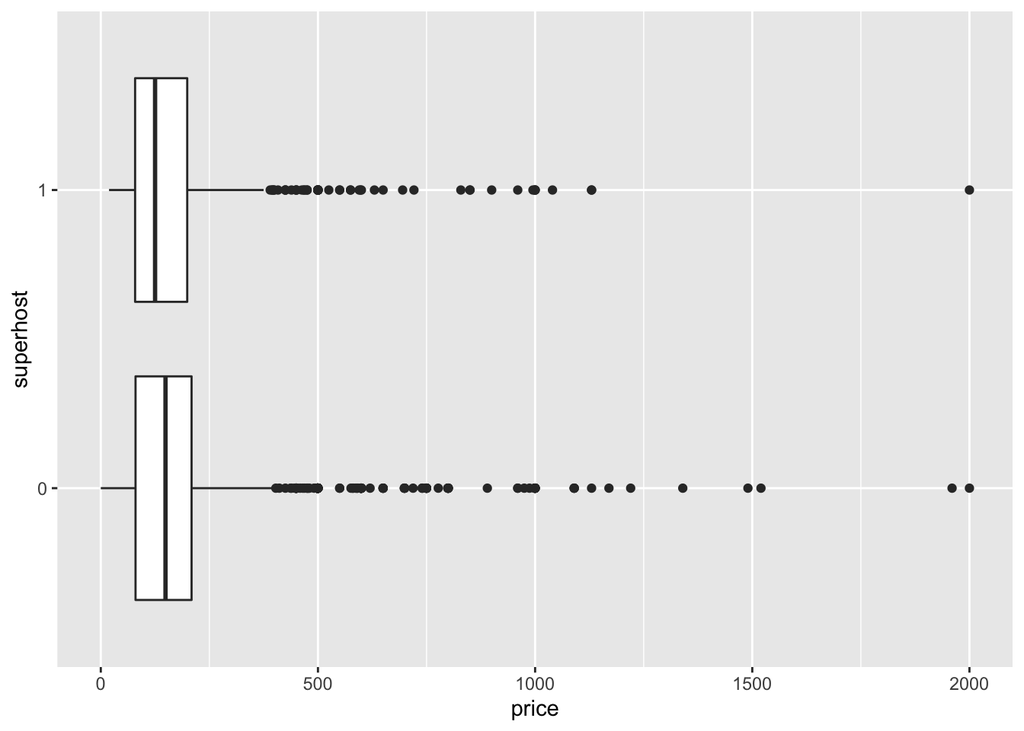

```r
bnb_filt <- filter(airbnb, price < 2500) %>%
  mutate(superhost = factor(superhost))

ggplot(bnb_filt, aes(price, superhost)) +
  geom_boxplot()
```

The first thing you may notices is that we no longer had to specify the `group` aesthetic because we converted `superhost` to a non-numeric format. From the above visualization it looks like that being a superhost does not necessarily increase the price of a listing. We can now test these means by using `t.test()`. There are a number of ways in which we can use this function but the most generalizable way is to use what is called the **formula** interface.

The formula interface is a way of defining *statistical* formulae. Or maybe a bit more clearly it let’s us tell R which columns to use when fitting a model[^2]. The general format it takes is `y ~ x` which reads *y as a function of x*. In the case of a t-test the `y` is the variable that we will be testing the means of and the `x` is what group to compare. If our data are already in a tidy format—like our Airbnb data—this will be rather easy to adhere to.

To perform a t-test we will use the `t.test()` function with the arguments `formula` and `data`. An example call looks like `t.test(y ~ x, data = df)`. In our case our `y` is `price` because it is our variable of interest or our dependent variable. Since we are curious how `price` changes by `superhost` status, we will put `superhost` in the `x` spot.

Conduct a t-test and store the results in `price_t`. Print it out afterwards.

```r
(price_t <- t.test(price ~ superhost, data = bnb_filt))
```

```
##
##  Welch Two Sample t-test
##
## data:  price by superhost
## t = 2.3261, df = 2029.4, p-value = 0.02011
## alternative hypothesis: true difference in means is not equal to 0
## 95 percent confidence interval:
##   1.949967 22.904491
## sample estimates:
## mean in group 0 mean in group 1
##        175.1989        162.7717
```

The above is a somewhat cluttered buch of numbers and words. But in there we can see our t-value (`t = 2.3261`), degrees of freedom (`df = 2029.4`), and our p-value (`p-value = 0.02011`). From this test we can tell that with an alpha level of 0.05 we can reject the null hypothesis.

While this is useful, we’re going to, at some point, want to extract these statistics in some usable format. Enter [`broom`](https://broom.tidyverse.org/)[^3]. From the documentation:

> "`broom` summarizes key information about models in tidy tibble()s. broom provides three verbs to make it convenient to interact with model objects.
> - tidy() summarizes information about model components
> - glance() reports information about the entire model
> - augment() adds informations about observations to a dataset[^4]

Make sure that broom is installed with `install.packages("broom")`.

```r
broom::tidy(price_t)
```

```
## # A tibble: 1 x 10
##   estimate estimate1 estimate2 statistic p.value parameter conf.low conf.high
##      <dbl>     <dbl>     <dbl>     <dbl>   <dbl>     <dbl>    <dbl>     <dbl>
## 1     12.4      175.      163.      2.33  0.0201     2029.     1.95      22.9
## # … with 2 more variables: method <chr>, alternative <chr>
```

```r
# t.test(price ~ superhost, data = airbnb_prices)
# aov(price ~ room_type, data = airbnb_prices)
# lm(price ~ superhost + room_type, data = airbnb_prices) %>%
#   summary()
```

## T-test

Only covering two-sample

`t.test()`

- two vectors
- using a data frame
- the formula interface
  - y ~ (by) x

## ANOVA

- we use anova when we want to test for 3 or more groups
- evaluates if there is *any* statistically significant differences between groups
- we do not know *which* groups, but just a group
- `aov()`
- uses the formula interface
- if we find that there may be statistically significant differences, we want to know between which groups there are differences.
- we do this with Tukey’s HSD

### Tukey’s HSD

Stands for Honestly Significant Difference

The function is `TukeyHSD()`

creates comparisons for all pairings

pretty cool, huh

## Linear regression

regression uses the formula interface as well

- y ~ beta
- create interaction terms with via multiplication `*`
- use the `lm()` function
[^1]: *R for Statistical Learning*. https://daviddalpiaz.github.io/r4sl/.
[^2]: *R for Dummies*. https://www.dummies.com/programming/r/how-to-use-the-formula-interface-in-r/.
[^3]: {broom} https://broom.tidyverse.org/.
[^4]: {broom} https://broom.tidyverse.org/.